# Ford GoBike System Data Explanation: Bike Hiring

## by (Nada Alzahrani)

## Investigation Overview

> This project is split into two main parts. In the first part, on Ford Gobike dataset, you can perform an exploratory data analysis. I will use data science and data visualization libraries from Python to explore the variables of the dataset and understand the structure, oddities, patterns and relationships of the data. The study should be organized in this section, ranging from simple univariate relationships to multivariate relationships. I will take my key conclusions from my exploration in the second part and express them through an explanatory analysis to others. To this end, to convey my findings, I will create a slide deck that leverages polished, explanatory visualizations.

## Dataset Overview

> This data set includes information about individual rides made in a bike-sharing system covering the greater San Francisco Bay area, in 2019.

## Distribution of Duration (sec)

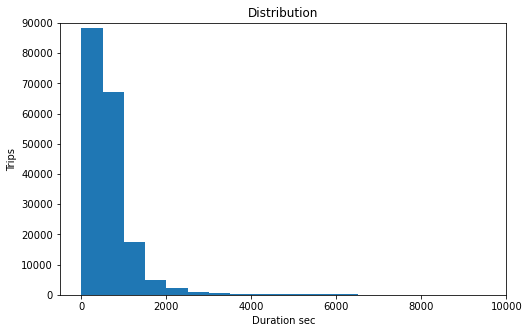

```python
binsize = 500
bins = np.arange(0, df['duration_sec'].max()+binsize, binsize)

plt.figure(figsize=[8, 5])
plt.hist(data = df, x = 'duration_sec', bins = bins)
plt.title('Distribution')
plt.xlabel('Duration sec')
plt.ylabel('Trips')
plt.axis([-500, 10000, 0, 90000])
plt.show();
```

## Average by user type

> I will further explore the dataset by Calculate average trip duration of "Subscribers" and "Customers"

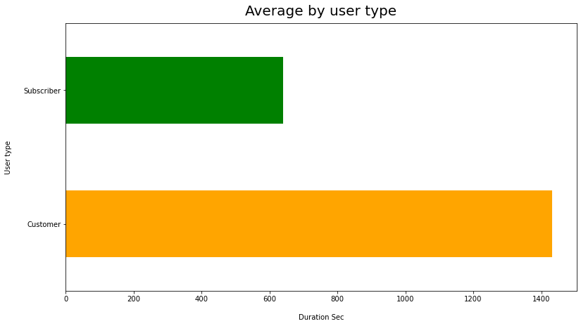

```python
colors=['orange', 'green']
axis = df.groupby('user_type')['duration_sec'].mean().plot(kind='barh', color=colors, figsize=(13,7))
axis.set_title('Average by user type', fontsize=20, y=1.015)
axis.set_ylabel('User type', labelpad=16)
axis.set_xlabel('Duration Sec', labelpad=16);
```

## duration (sec) distribution per user type and gender

> We can note here that females take longer trips "measured in time" than males and others in both cases. For consumers, the disparity is more evident "13 min for men and others vs 15 for women" than for subscribers.

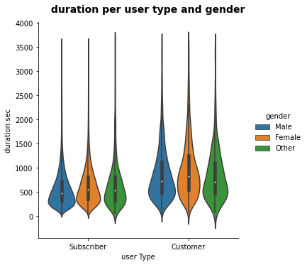

```python
data = df.query('duration_sec < 3600')
n = sb.catplot(data=data, x='user_type', y="duration_sec", hue="member_gender",
               kind="violin")


n.set_axis_labels("user Type", "duration sec")
n._legend.set_title('gender')
n.fig.suptitle(' duration per user type and gender',
               y=1.03, fontsize=14, fontweight='semibold');
```

# Summary

> Renting a Ford GoBike System bike is a perfect way to ride around in urban areas, both for fun and for work "healthy and environmentally friendly". There are two groups of clients: subscribers and customers.